# EDA and Modeling Plans

### Cleaning up dataset

```r
survey2=survey[survey$Age<=100 & survey$Age>=0,]
survey2$mental_health_consequence= ifelse(survey2$mental_health_consequence=="Yes","yes","no")
survey2$benefits= ifelse(survey2$benefits=="Yes","yes","no")
survey2$seek_help=ifelse(survey2$seek_help=="Yes","yes","no")
survey2$wellness_program=ifelse(survey2$wellness_program=="Yes","yes","no")
survey2$anonymity= ifelse(survey2$anonymity=="Yes","yes","no")
survey2$care_options= ifelse(survey2$care_options=="Yes","yes","no")
survey2$obs_consequence=ifelse(survey2$obs_consequence=="Yes","yes","no")
survey2$supervisor=ifelse(survey2$supervisor=="Yes","yes","no")
survey2$mental_vs_physical=ifelse(survey2$mental_vs_physical=="Yes","yes","no")
survey2$leave=ifelse(survey2$leave=="Very difficult" | survey2$leave=="Somewhat difficult","yes","no")

##Gender
survey2$Gender = ifelse(survey2$Gender == "Cis Female", "F",as.character(survey2$Gender))
survey2$Gender = ifelse(survey2$Gender == "cis-female/femme", "F",as.character(survey2$Gender))
survey2$Gender = ifelse(survey2$Gender == "f", "F",as.character(survey2$Gender))
survey2$Gender = ifelse(survey2$Gender == "femail", "F",as.character(survey2$Gender))
survey2$Gender = ifelse(survey2$Gender == "Femake", "F",as.character(survey2$Gender))
survey2$Gender = ifelse(survey2$Gender == "female", "F",as.character(survey2$Gender))
survey2$Gender = ifelse(survey2$Gender == "Female", "F", as.character(survey2$Gender))
survey2$Gender = ifelse(survey2$Gender == "Female ", "F",as.character(survey2$Gender))
survey2$Gender = ifelse(survey2$Gender == "Female 'cis'", "F",as.character(survey2$Gender))
survey2$Gender = ifelse(survey2$Gender == "woman", "F", as.character(survey2$Gender))
survey2$Gender = ifelse(survey2$Gender == "Woman", "F",as.character(survey2$Gender))
survey2$Gender = ifelse(survey2$Gender == "Female (cis) ", "F",as.character(survey2$Gender))
survey2$Gender = ifelse(survey2$Gender == "Female (cis)", "F",as.character(survey2$Gender))
survey2$Gender = ifelse(survey2$Gender == "Female (trans)", "F",as.character(survey2$Gender))
survey2$Gender = ifelse(survey2$Gender == "Trans woman", "F",as.character(survey2$Gender))
survey2$Gender = ifelse(survey2$Gender == "Trans-female", "F",as.character(survey2$Gender))



###male

survey2$Gender = ifelse(survey2$Gender == "cis male", "M",as.character(survey2$Gender))
survey2$Gender = ifelse(survey2$Gender == "Cis Man", "M",as.character(survey2$Gender))
survey2$Gender = ifelse(survey2$Gender == "Cis Male", "M",as.character(survey2$Gender))
survey2$Gender = ifelse(survey2$Gender == "m", "M",as.character(survey2$Gender))
survey2$Gender = ifelse(survey2$Gender == "Mail", "M",as.character(survey2$Gender))
survey2$Gender = ifelse(survey2$Gender == "Make", "M",as.character(survey2$Gender))
survey2$Gender = ifelse(survey2$Gender == "Mal", "M",as.character(survey2$Gender))
survey2$Gender = ifelse(survey2$Gender == "Male", "M",as.character(survey2$Gender))
survey2$Gender = ifelse(survey2$Gender == "maile", "M",as.character(survey2$Gender))
survey2$Gender = ifelse(survey2$Gender == "Male ", "M",as.character(survey2$Gender))
survey2$Gender = ifelse(survey2$Gender == "Male (CIS)", "M",as.character(survey2$Gender))
survey2$Gender = ifelse(survey2$Gender == "Malr", "M",as.character(survey2$Gender))
survey2$Gender = ifelse(survey2$Gender == "Man", "M",as.character(survey2$Gender))
survey2$Gender = ifelse(survey2$Gender == "Male-ish", "M",as.character(survey2$Gender))
survey2$Gender = ifelse(survey2$Gender == "something kinda male?", "M",as.character(survey2$Gender))
survey2$Gender = ifelse(survey2$Gender == "male", "M",as.character(survey2$Gender))
survey2$Gender = ifelse(survey2$Gender == "msle", "M",as.character(survey2$Gender))
survey2$Gender = ifelse(survey2$Gender == "Guy (-ish) ^_^", "M",as.character(survey2$Gender))

###other

survey2$Gender = ifelse(survey2$Gender == "Agender", "other",as.character(survey2$Gender))
survey2$Gender = ifelse(survey2$Gender == "All", "other",as.character(survey2$Gender))
survey2$Gender = ifelse(survey2$Gender == "Enby", "other",as.character(survey2$Gender))
survey2$Gender = ifelse(survey2$Gender == "A little about you", "other",as.character(survey2$Gender))
survey2$Gender = ifelse(survey2$Gender == "Androgyne", "other",as.character(survey2$Gender))
survey2$Gender = ifelse(survey2$Gender == "fluid", "other",as.character(survey2$Gender))
survey2$Gender = ifelse(survey2$Gender == "Genderqueer", "other",as.character(survey2$Gender))
survey2$Gender = ifelse(survey2$Gender == "male leaning androgynous", "other",as.character(survey2$Gender))
survey2$Gender = ifelse(survey2$Gender == "Neuter", "other",as.character(survey2$Gender))
survey2$Gender = ifelse(survey2$Gender == "ostensibly male, unsure what that really means", "other",as.character(survey2$Gender))
survey2$Gender = ifelse(survey2$Gender == "Nah", "other",as.character(survey2$Gender))
survey2$Gender = ifelse(survey2$Gender == "p", "other",as.character(survey2$Gender))
survey2$Gender = ifelse(survey2$Gender == "queer", "other",as.character(survey2$Gender))
survey2$Gender = ifelse(survey2$Gender == "queer/she/they", "other",as.character(survey2$Gender))
survey2$Gender = ifelse(survey2$Gender == "", "other",as.character(survey2$Gender))
survey2$Gender = ifelse(survey2$Gender == "queer/she/they", "other",as.character(survey2$Gender))
survey2$Gender = ifelse(survey2$Gender == "non-binary", "other",as.character(survey2$Gender))
```

### EDA

*Wellness Program vs. Treatment*

```r
table1=table(survey2$wellness_program,survey2$treatment)
addmargins(table1)
```

```
##
##         No  Yes  Sum
##   no   528  498 1026
##   yes   93  135  228
##   Sum  621  633 1254
```

```r
rownames(table1)=c("No Program","Program")
colnames(table1)=c("No Treatment","Treatment")
tableofprops1 = prop.table(table1,margin=2)
tableofprops1
```

```
##
##              No Treatment Treatment
##   No Program    0.8502415 0.7867299
##   Program       0.1497585 0.2132701
```

The proportion of people in the wellness program who get treatment(0.21) is higher than people in the control group who get treatment(0.15), which has a difference from the treatment group(6% difference).

*Benefit vs. Treatment*

```r
table2=table(survey2$benefits,survey2$treatment)
addmargins(table2)
```

```
##
##         No  Yes  Sum
##   no   450  330  780
##   yes  171  303  474
##   Sum  621  633 1254
```

```r
rownames(table2)=c("No Benefit","Benefit")
colnames(table2)=c("No Treatment","Treatment")
tableofprops2 = prop.table(table2,margin=2)
tableofprops2
```

```
##
##              No Treatment Treatment
##   No Benefit    0.7246377 0.5213270
##   Benefit       0.2753623 0.4786730
```

The proportion of people in the treatment group who get benefit from companies(0.48) is higher than people in the control group who get benefit from companies(0.28), which is a significant difference from the treatment group(20% difference).

*Age vs. Treatment*

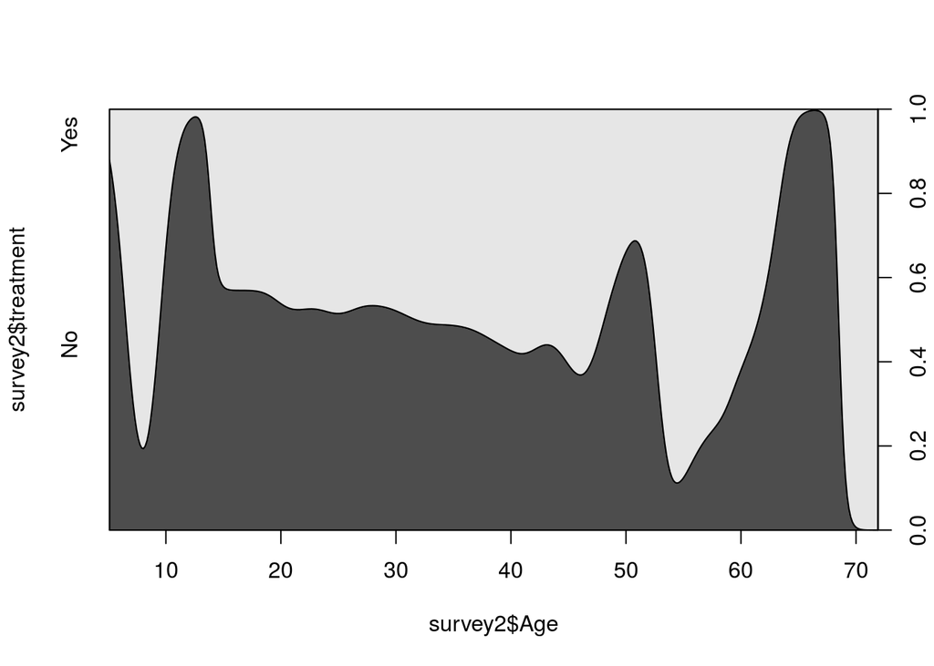

```r
cdplot(survey2$treatment~survey2$Age)
```

```r
favstats(survey2$Age~survey2$treatment)
```

```
##   survey2$treatment min Q1 median Q3 max     mean       sd   n missing
## 1                No   5 27     31 35  65 31.45894 7.084081 621       0
## 2               Yes   8 27     32 37  72 32.56872 7.615281 633       0
```

Cdplot shows that there is no relationship between Treatment and Age(not linear). Statistical summary also indicates that there is not a big difference of means between Treatment and Control groups(31 vs 33).

*Mental vs. Treatment*

```r
table3=table(survey2$mental_health_consequence,survey2$treatment)
addmargins(table3)
```

```
##
##         No  Yes  Sum
##   no   503  462  965
##   yes  118  171  289
##   Sum  621  633 1254
```

```r
rownames(table3)=c("No mental health consequence","Mental Health consequence")
colnames(table3)=c("No Seek treatment","Seek treatment")
tableofprops3 = prop.table(table3,margin=2)
tableofprops3
```

```
##
##                                No Seek treatment Seek treatment
##   No mental health consequence         0.8099839      0.7298578
##   Mental Health consequence            0.1900161      0.2701422
```

The proportion of people who think that discussing a mental health issue with their employer would have negative consequences that seek help is 0.27. The proportion of people who don’t think so that seek help is 0.19, which has a difference from the treatment group(8% difference).

*Care option versus Treatment*

```r
table4=table(survey2$care_options,survey2$treatment)
addmargins(table4)
```

```
##
##         No  Yes  Sum
##   no   484  329  813
##   yes  137  304  441
##   Sum  621  633 1254
```

```r
rownames(table4)=c("Don't know care option","Know care option")
colnames(table4)=c("No Seek treatment","Seek treatment")
tableofprops4 = prop.table(table4,margin=2)
tableofprops4
```

```
##
##                          No Seek treatment Seek treatment
##   Don't know care option         0.7793881      0.5197472
##   Know care option               0.2206119      0.4802528
```

*Leave versus Treatment*

```r
table5=table(survey2$leave,survey2$treatment)
addmargins(table5)
```

```
##
##         No  Yes  Sum
##   no   546  486 1032
##   yes   75  147  222
##   Sum  621  633 1254
```

```r
rownames(table5)=c("Difficult","Easy")
colnames(table5)=c("No Seek treatment","Seek treatment")
tableofprops5 = prop.table(table5,margin=2)
tableofprops5
```

```
##
##             No Seek treatment Seek treatment
##   Difficult         0.8792271      0.7677725
##   Easy              0.1207729      0.2322275
```

*Anonymity versus Treatment*

```r
table6=table(survey2$anonymity,survey2$treatment)
addmargins(table6)
```

```
##
##         No  Yes  Sum
##   no   474  406  880
##   yes  147  227  374
##   Sum  621  633 1254
```

```r
rownames(table6)=c("Protected","Not Protected")
colnames(table6)=c("No Seek treatment","Seek treatment")
tableofprops6= prop.table(table6,margin=2)
tableofprops6
```

```
##
##                 No Seek treatment Seek treatment
##   Protected             0.7632850      0.6413902
##   Not Protected         0.2367150      0.3586098
```

The proportion of people,whose anonymity is protected to get treatment,in the treatment group is 0.36. The proportion of people, whose anonymity is protected to get treatment, in the control group is 0.24, which is a significant difference from the treatment group(12% difference).

*Observed Sequences versus Treatment*

```r
table7=table(survey2$obs_consequence,survey2$treatment)
addmargins(table7)
```

```
##
##         No  Yes  Sum
##   no   565  507 1072
##   yes   56  126  182
##   Sum  621  633 1254
```

```r
rownames(table7)=c("Heard","Not Heard")
colnames(table7)=c("No Seek treatment","Seek treatment")
tableofprops7= prop.table(table7,margin=2)
tableofprops7
```

```
##
##             No Seek treatment Seek treatment
##   Heard            0.90982287     0.80094787
##   Not Heard        0.09017713     0.19905213
```

The proportion of people,who heard or obeserved negative consequences for coworkers with mental health conditions in their work place,in the treatment group is 0.20. The proportion of people,who heard or obeserved negative consequences for coworkers with mental health conditions in their work place,in the control group is 0.09, which is a significant difference from the treatment group(11% difference).

*Mental vs Physical versus Treatment*

```r
table8=table(survey2$mental_vs_physical,survey2$treatment)
addmargins(table8)
```

```
##
##         No  Yes  Sum
##   no   453  459  912
##   yes  168  174  342
##   Sum  621  633 1254
```

```r
rownames(table8)=c("Yes","No")
colnames(table8)=c("No Seek treatment","Seek treatment")
tableofprops8=prop.table(table8,margin=2)
tableofprops8
```

```
##
##       No Seek treatment Seek treatment
##   Yes         0.7294686      0.7251185
##   No          0.2705314      0.2748815
```

The proportion of people,whose employer takes mental health as seriously as physical health,in the treatment group is 0.27. The proportion of people,whose employer takes mental health as seriously as physical health,in the control group is 0.27, which is the same as the treatment group.

***Supervisor vs Physical versus Treatment**

```r
table9=table(survey2$supervisor,survey2$treatment)
addmargins(table9)
```

```
##
##         No  Yes  Sum
##   no   356  384  740
##   yes  265  249  514
##   Sum  621  633 1254
```

```r
rownames(table9)=c("Yes","No")
colnames(table9)=c("No Seek treatment","Seek treatment")
tableofprops9= prop.table(table9,margin=2)
tableofprops9
```

```
##
##       No Seek treatment Seek treatment
##   Yes         0.5732689      0.6066351
##   No          0.4267311      0.3933649
```

The proportion of people,who is willing to discuss a mental health issue with your direct supervisor,in the treatment group is 0.39. The proportion of people,who is willing to discuss a mental health issue with your direct supervisor,in the control group is 0.43, which is a small difference from the treatment group(4% difference).

*Gender vs Physical versus Treatment*

```r
table10=table(survey2$Gender,survey2$treatment)
addmargins(table10)
```

```
##
##           No  Yes  Sum
##   F       78  173  251
##   M      541  449  990
##   other    2   11   13
##   Sum    621  633 1254
```

```r
colnames(table10)=c("No Seek treatment","Seek treatment")
tableofprops10= prop.table(table10,margin=2)
tableofprops10
```

```
##
##         No Seek treatment Seek treatment
##   F           0.125603865    0.273301738
##   M           0.871175523    0.709320695
##   other       0.003220612    0.017377567
```

### Model Selction

Our response variable is Treatment, and we believe that there is a relationship between Treatment and Benefit, Wellness Program, Age, Mental Consequence, Care Options, Supervisor, Observed Sequences, Gender, Leave, Mental vs physical, and Anonymity. We are going to explore our models!

```r
Model1=glm(treatment~benefits+Age+mental_health_consequence+wellness_program+care_options+anonymity+obs_consequence+supervisor+Gender+leave+mental_vs_physical,data=survey2,family=binomial);summary(Model1)
```

```
##
## Call:
## glm(formula = treatment ~ benefits + Age + mental_health_consequence +
##     wellness_program + care_options + anonymity + obs_consequence +
##     supervisor + Gender + leave + mental_vs_physical, family = binomial,
##     data = survey2)
##
## Deviance Residuals:
##     Min       1Q   Median       3Q      Max
## -2.6331  -0.9915   0.3971   1.0123   1.7087
##
## Coefficients:
##                               Estimate Std. Error z value Pr(>|z|)
## (Intercept)                  -0.458018   0.304933  -1.502 0.133089
## benefitsyes                   0.569236   0.150729   3.777 0.000159 ***
## Age                           0.013110   0.008599   1.525 0.127359
## mental_health_consequenceyes  0.190848   0.165643   1.152 0.249252
## wellness_programyes          -0.303038   0.184629  -1.641 0.100727
## care_optionsyes               0.859954   0.149743   5.743 9.31e-09 ***
## anonymityyes                  0.197903   0.155461   1.273 0.203017
## obs_consequenceyes            0.610561   0.191032   3.196 0.001393 **
## supervisoryes                 0.046482   0.138367   0.336 0.736923
## GenderM                      -0.870394   0.162294  -5.363 8.18e-08 ***
## Genderother                   0.985113   0.813424   1.211 0.225869
## leaveyes                      0.629096   0.176069   3.573 0.000353 ***
## mental_vs_physicalyes        -0.069336   0.153032  -0.453 0.650489
## ---
## Signif. codes:  0 '***' 0.001 '**' 0.01 '*' 0.05 '.' 0.1 ' ' 1
##
## (Dispersion parameter for binomial family taken to be 1)
##
##     Null deviance: 1738.3  on 1253  degrees of freedom
## Residual deviance: 1545.0  on 1241  degrees of freedom
## AIC: 1571
##
## Number of Fisher Scoring iterations: 4
```

```r
vif(Model1)
```

```
##                               GVIF Df GVIF^(1/(2*Df))
## benefits                  1.410977  1        1.187845
## Age                       1.055203  1        1.027231
## mental_health_consequence 1.266087  1        1.125205
## wellness_program          1.335889  1        1.155807
## care_options              1.323288  1        1.150343
## anonymity                 1.329426  1        1.153007
## obs_consequence           1.078291  1        1.038408
## supervisor                1.244029  1        1.115360
## Gender                    1.051593  2        1.012656
## leave                     1.143701  1        1.069440
## mental_vs_physical        1.257073  1        1.121193
```

```r
###Backward elimination(we did not include in our model)
step(Model1,direction = "backward")
```

```
## Start:  AIC=1571.05
## treatment ~ benefits + Age + mental_health_consequence + wellness_program +
##     care_options + anonymity + obs_consequence + supervisor +
##     Gender + leave + mental_vs_physical
##
##                             Df Deviance    AIC
## - supervisor                 1   1545.2 1569.2
## - mental_vs_physical         1   1545.2 1569.2
## - mental_health_consequence  1   1546.4 1570.4
## - anonymity                  1   1546.7 1570.7
## <none>                           1545.0 1571.0
## - Age                        1   1547.4 1571.4
## - wellness_program           1   1547.8 1571.8
## - obs_consequence            1   1555.5 1579.5
## - leave                      1   1558.0 1582.0
## - benefits                   1   1559.3 1583.3
## - Gender                     2   1580.4 1602.4
## - care_options               1   1578.6 1602.6
##
## Step:  AIC=1569.16
## treatment ~ benefits + Age + mental_health_consequence + wellness_program +
##     care_options + anonymity + obs_consequence + Gender + leave +
##     mental_vs_physical
##
##                             Df Deviance    AIC
## - mental_vs_physical         1   1545.3 1567.3
## - mental_health_consequence  1   1546.4 1568.4
## - anonymity                  1   1546.9 1568.9
## <none>                           1545.2 1569.2
## - Age                        1   1547.5 1569.5
## - wellness_program           1   1547.8 1569.8
## - obs_consequence            1   1555.6 1577.6
## - leave                      1   1558.1 1580.1
## - benefits                   1   1559.4 1581.4
## - Gender                     2   1580.5 1600.5
## - care_options               1   1578.8 1600.8
##
## Step:  AIC=1567.31
## treatment ~ benefits + Age + mental_health_consequence + wellness_program +
##     care_options + anonymity + obs_consequence + Gender + leave
```

[output cut: 26 more lines]

```
## - Gender            2   1582.9 1598.9
##
## Step:  AIC=1565.96
## treatment ~ benefits + Age + wellness_program + care_options +
##     obs_consequence + Gender + leave
##
##                    Df Deviance    AIC
## <none>                  1548.0 1566.0
## - Age               1   1550.3 1566.3
## - wellness_program  1   1550.4 1566.4
## - obs_consequence   1   1559.8 1575.8
## - benefits          1   1563.8 1579.8
## - leave             1   1564.4 1580.4
## - Gender            2   1583.7 1597.7
## - care_options      1   1588.8 1604.8
```

```
##
## Call:  glm(formula = treatment ~ benefits + Age + wellness_program +
##     care_options + obs_consequence + Gender + leave, family = binomial,
##     data = survey2)
##
## Coefficients:
##         (Intercept)          benefitsyes                  Age
##            -0.40733              0.59303              0.01313
## wellness_programyes      care_optionsyes   obs_consequenceyes
##            -0.28153              0.90757              0.63742
##             GenderM          Genderother             leaveyes
##            -0.86074              1.01747              0.68230
##
## Degrees of Freedom: 1253 Total (i.e. Null);  1245 Residual
## Null Deviance:       1738
## Residual Deviance: 1548  AIC: 1566
```

Benefit, Care Option, Observed Consequences, Gender(Male), and Leave have significant p-values.From multicolinearity test, we verified that variables are not highly correlated to each other(around 1).

We will remove variables that have insignificant p-values and remodel them.

```r
Model2=glm(treatment~benefits+care_options+obs_consequence+Gender+leave,data=survey2,family=binomial);summary(Model2)
```

```
##
## Call:
## glm(formula = treatment ~ benefits + care_options + obs_consequence +
##     Gender + leave, family = binomial, data = survey2)
##
## Deviance Residuals:
##     Min       1Q   Median       3Q      Max
## -2.5059  -1.0427   0.3550   0.9695   1.5616
##
## Coefficients:
##                    Estimate Std. Error z value Pr(>|z|)
## (Intercept)        -0.03258    0.16048  -0.203 0.839123
## benefitsyes         0.54365    0.13885   3.915 9.02e-05 ***
## care_optionsyes     0.88270    0.14076   6.271 3.59e-10 ***
## obs_consequenceyes  0.63388    0.18734   3.384 0.000716 ***
## GenderM            -0.83645    0.15932  -5.250 1.52e-07 ***
## Genderother         0.90618    0.80762   1.122 0.261851
## leaveyes            0.70526    0.16956   4.159 3.19e-05 ***
## ---
## Signif. codes:  0 '***' 0.001 '**' 0.01 '*' 0.05 '.' 0.1 ' ' 1
##
## (Dispersion parameter for binomial family taken to be 1)
##
##     Null deviance: 1738.3  on 1253  degrees of freedom
## Residual deviance: 1552.5  on 1247  degrees of freedom
## AIC: 1566.5
##
## Number of Fisher Scoring iterations: 4
```

All of the variables except Genderother(Female/Other) have significant p-values. There is no noticeable difference for deviance and AIC values from Model 1.

```r
anova(Model1,Model2,test="Chisq")#drop in deviance test
```

```
## Analysis of Deviance Table
##
## Model 1: treatment ~ benefits + Age + mental_health_consequence + wellness_program +
##     care_options + anonymity + obs_consequence + supervisor +
##     Gender + leave + mental_vs_physical
## Model 2: treatment ~ benefits + care_options + obs_consequence + Gender +
##     leave
##   Resid. Df Resid. Dev Df Deviance Pr(>Chi)
## 1      1241     1545.0
## 2      1247     1552.5 -6  -7.4731   0.2793
```

From drop in deviance test, we conclude that simple(Model2) is a better model to predict odds of Treatment due to a large p-value(0.28).

From EDA, we believe that Benefit, Care Option, Leave, Anonymity, and Observed Sequences(more than 10% difference between the treatment and control) will give us a statistically significant model.

```r
Model3=glm(treatment~benefits+care_options+obs_consequence+leave,data=survey2,family=binomial);summary(Model3)
```

```
##
## Call:
## glm(formula = treatment ~ benefits + care_options + obs_consequence +
##     leave, family = binomial, data = survey2)
##
## Deviance Residuals:
##     Min       1Q   Median       3Q      Max
## -2.1325  -0.8866   0.4661   1.1112   1.4993
##
## Coefficients:
##                    Estimate Std. Error z value Pr(>|z|)
## (Intercept)        -0.73084    0.08794  -8.311  < 2e-16 ***
## benefitsyes         0.61061    0.13666   4.468 7.89e-06 ***
## care_optionsyes     0.88864    0.13898   6.394 1.62e-10 ***
## obs_consequenceyes  0.67807    0.18400   3.685 0.000229 ***
## leaveyes            0.71876    0.16762   4.288 1.80e-05 ***
## ---
## Signif. codes:  0 '***' 0.001 '**' 0.01 '*' 0.05 '.' 0.1 ' ' 1
##
## (Dispersion parameter for binomial family taken to be 1)
##
##     Null deviance: 1738.3  on 1253  degrees of freedom
## Residual deviance: 1586.3  on 1249  degrees of freedom
## AIC: 1596.3
##
## Number of Fisher Scoring iterations: 4
```

```r
anova(Model3,Model2,test="Chisq")
```

```
## Analysis of Deviance Table
##
## Model 1: treatment ~ benefits + care_options + obs_consequence + leave
## Model 2: treatment ~ benefits + care_options + obs_consequence + Gender +
##     leave
##   Resid. Df Resid. Dev Df Deviance  Pr(>Chi)
## 1      1249     1586.3
## 2      1247     1552.5  2   33.805 4.564e-08 ***
## ---
## Signif. codes:  0 '***' 0.001 '**' 0.01 '*' 0.05 '.' 0.1 ' ' 1
```

All of the variables have significant p-values. And when we did drop in deviance with Model 2, it showed that the full model(Model 2) is a better predictor for Treatment due to a small p-value.

*Best subset approach*

Since the most of our variables are categorical variables(except Age), we will not use best Adjusted-R model. We are going to perform Best.cp model and Best. bic model.

```r
best3=regsubsets(treatment~benefits+Age+mental_health_consequence+wellness_program+care_options+anonymity+obs_consequence+supervisor+Gender+leave+mental_vs_physical,nbest=3,data=survey2)
summary(best3)
```

```
## Subset selection object
## Call: regsubsets.formula(treatment ~ benefits + Age + mental_health_consequence +
##     wellness_program + care_options + anonymity + obs_consequence +
##     supervisor + Gender + leave + mental_vs_physical, nbest = 3,
##     data = survey2)
## 12 Variables  (and intercept)
##                              Forced in Forced out
## benefitsyes                      FALSE      FALSE
## Age                              FALSE      FALSE
## mental_health_consequenceyes     FALSE      FALSE
## wellness_programyes              FALSE      FALSE
## care_optionsyes                  FALSE      FALSE
## anonymityyes                     FALSE      FALSE
## obs_consequenceyes               FALSE      FALSE
## supervisoryes                    FALSE      FALSE
```

[output cut: 81 more lines]

```r
round(summary(best3)$cp,3)#19th row(7(1))
```

```
##  [1]  91.992 135.412 142.001  51.425  69.628  69.747  30.692  33.509
##  [9]  42.953  16.853  21.237  24.097   7.540  16.012  16.096   7.301
## [17]   7.695   8.147   7.241   8.056   8.064   7.794   7.930   8.051
```

We found that 19th row has the smallest cp, which includes Benefits, Age, Wellness Program, Care Option,Observed Consequence, Gender,and Leave.

```r
Model4=glm(treatment~benefits+Age+wellness_program+care_options+obs_consequence+Gender+leave,data=survey2,family=binomial)##Best.cp Model
summary(Model4)
```

```
##
## Call:
## glm(formula = treatment ~ benefits + Age + wellness_program +
##     care_options + obs_consequence + Gender + leave, family = binomial,
##     data = survey2)
##
## Deviance Residuals:
##     Min       1Q   Median       3Q      Max
## -2.5672  -1.0022   0.3974   1.0083   1.7204
##
## Coefficients:
##                      Estimate Std. Error z value Pr(>|z|)
## (Intercept)         -0.407329   0.295838  -1.377 0.168554
## benefitsyes          0.593032   0.149013   3.980 6.90e-05 ***
## Age                  0.013125   0.008557   1.534 0.125079
## wellness_programyes -0.281533   0.180409  -1.561 0.118635
## care_optionsyes      0.907570   0.143372   6.330 2.45e-10 ***
## obs_consequenceyes   0.637421   0.188230   3.386 0.000708 ***
## GenderM             -0.860737   0.160552  -5.361 8.27e-08 ***
## Genderother          1.017466   0.811410   1.254 0.209861
## leaveyes             0.682303   0.170239   4.008 6.13e-05 ***
## ---
## Signif. codes:  0 '***' 0.001 '**' 0.01 '*' 0.05 '.' 0.1 ' ' 1
##
## (Dispersion parameter for binomial family taken to be 1)
##
##     Null deviance: 1738.3  on 1253  degrees of freedom
## Residual deviance: 1548.0  on 1245  degrees of freedom
## AIC: 1566
##
## Number of Fisher Scoring iterations: 4
```

Benefit, Care Option, Observed Consequence, Gender(Male), Leave have significant p-values.

```r
round(summary(best3)$bic,3)#13th row
```

```
##  [1]  -82.021  -42.091  -36.140 -115.307  -97.862  -97.749 -130.306
##  [8] -127.542 -118.321 -138.826 -134.474 -131.643 -142.995 -134.522
## [15] -134.437 -138.110 -137.713 -137.260 -133.048 -132.228 -132.220
## [22] -127.373 -127.235 -127.113
```

We found that 13th row has the smallest bic, which includes Benefits, Care Option, Observed Consequence, Gender, Leave.

```r
Model5=glm(treatment~benefits+care_options+obs_consequence+Gender+leave,data=survey2,family=binomial)##Best.bic Model
summary(Model5)
```

```
##
## Call:
## glm(formula = treatment ~ benefits + care_options + obs_consequence +
##     Gender + leave, family = binomial, data = survey2)
##
## Deviance Residuals:
##     Min       1Q   Median       3Q      Max
## -2.5059  -1.0427   0.3550   0.9695   1.5616
##
## Coefficients:
##                    Estimate Std. Error z value Pr(>|z|)
## (Intercept)        -0.03258    0.16048  -0.203 0.839123
## benefitsyes         0.54365    0.13885   3.915 9.02e-05 ***
## care_optionsyes     0.88270    0.14076   6.271 3.59e-10 ***
## obs_consequenceyes  0.63388    0.18734   3.384 0.000716 ***
## GenderM            -0.83645    0.15932  -5.250 1.52e-07 ***
## Genderother         0.90618    0.80762   1.122 0.261851
## leaveyes            0.70526    0.16956   4.159 3.19e-05 ***
## ---
## Signif. codes:  0 '***' 0.001 '**' 0.01 '*' 0.05 '.' 0.1 ' ' 1
##
## (Dispersion parameter for binomial family taken to be 1)
##
##     Null deviance: 1738.3  on 1253  degrees of freedom
## Residual deviance: 1552.5  on 1247  degrees of freedom
## AIC: 1566.5
##
## Number of Fisher Scoring iterations: 4
```

```r
anova(Model4,Model5,test="Chisq")##Simpler model is better! (insignificant p-value)
```

```
## Analysis of Deviance Table
##
## Model 1: treatment ~ benefits + Age + wellness_program + care_options +
##     obs_consequence + Gender + leave
## Model 2: treatment ~ benefits + care_options + obs_consequence + Gender +
##     leave
##   Resid. Df Resid. Dev Df Deviance Pr(>Chi)
## 1      1245     1548.0
## 2      1247     1552.5 -2  -4.5559   0.1025
```

```r
exp(confint(Model5))
```

```
##                        2.5 %    97.5 %
## (Intercept)        0.7075083  1.328372
## benefitsyes        1.3119366  2.261705
## care_optionsyes    1.8365300  3.190000
## obs_consequenceyes 1.3100631  2.733630
## GenderM            0.3159496  0.590397
## Genderother        0.6028426 16.806216
## leaveyes           1.4552429  2.830895
```

Except Gender Other, all of the variables have significant p-values. Comparing Best.cp(Model 4) to Best.bic(Model 5), using drop in deviance test, we conclude that simple model(Model 5) is a better model to predict Treatment due to a large p-value(0.1). It is also interesting to find that Model 2 is the same model as Best.bic model.